# Reproducible Research: Peer Assessment 1

The main thing that you have to remember on this journey is, just be nice to everyone and always smile.

## Loading and preprocessing the data

1. Show any code that is needed to Load the data (i.e. read.csv())

```r
## 1.
file <-  "activity.zip"
##unzip
data <- read.csv(unz(file, "activity.csv"))
```

2. Process/transform the data (if necessary) into a format suitable for your analysis

```r
## 2. transform for easier processing
data$steps <- as.numeric(data$steps)
data$interval <- as.numeric(data$interval)
data$date <- as.Date(data$date)
```

## dataframe the way we want it

```r
total.steps.daily <- aggregate(steps ~ date, data=data, sum, na.rm=TRUE)
```

## 2b. Also install needed tools

```r
library(latticeExtra)
library(lattice)
```

## What is mean total number of steps taken per day?

1.Make a histogram of the total number of steps taken each day

The histogram looks like this:

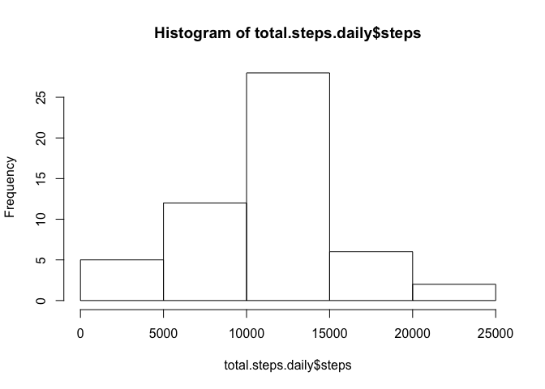

```r
hist(total.steps.daily$steps)
```

But I think this chart shoes better the daily steps:

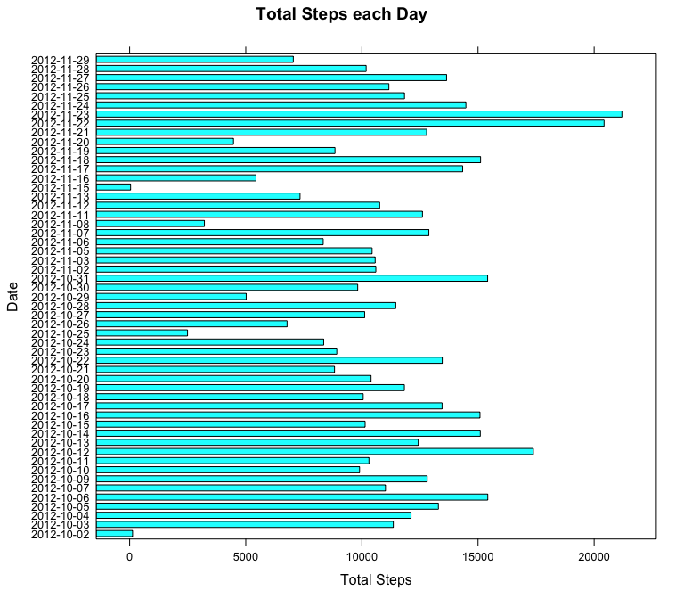

```r
barchart(total.steps.daily$date ~ total.steps.daily$steps,
         main = "Total Steps each Day",
         xlab = "Total Steps", ylab = "Date",
         par.strip.text = list(cex = 5),)
```

2.Calculate and report the mean and median total number of steps taken per day

```r
mean(total.steps.daily$steps)
```

```
## [1] 10766.19
```

```r
median(total.steps.daily$steps)
```

```
## [1] 10765
```

## What is the average daily activity pattern?

1. Make a time series plot (i.e. type = “l”) of the 5-minute interval (x-axis) and the average number of steps taken, averaged across all days (y-axis)
2. Which 5-minute interval, on average across all the days in the dataset, contains the maximum number of steps?

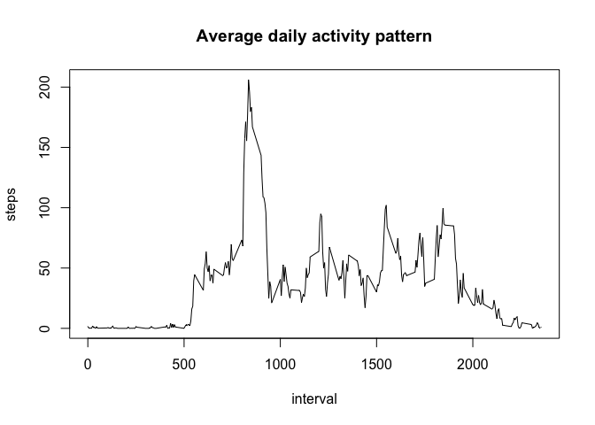

```r
average.steps.per.interval <- aggregate(steps ~ interval, data, mean)
plot(average.steps.per.interval, type = "l", main = "Average daily activity pattern")
```

2. Which 5-minute interval, on average across all the days in the dataset, contains the maximum number of steps?

```r
subset(average.steps.per.interval, steps == max(steps))
```

```
##     interval    steps
## 104      835 206.1698
```

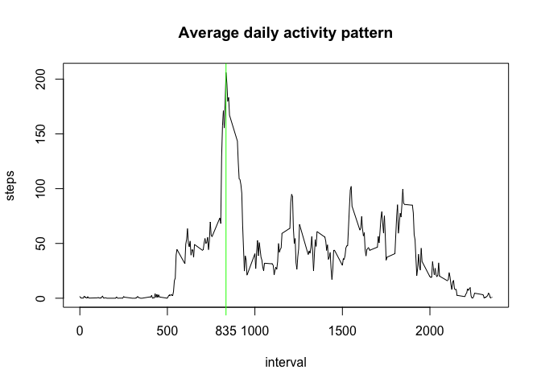

```r
max.interval <- subset(average.steps.per.interval, steps == max(steps))
plot(average.steps.per.interval, type = "l", main = "Average daily activity pattern")
abline(v = max.interval$interval, col = "green", lwd = 1)
axis(1, at=max.interval$interval,labels=max.interval$interval, col="green")
```